# TP3: Regresión logística sobre el Adult Census Income

Autor/a

Paulucci, Inés

Fecha de publicación

2 de junio de 2026

# Introducción

En este trabajo aplicamos **regresión logística binomial** para modelar la probabilidad de que un individuo del *Adult Census Income* (microdatos del censo de EE. UU.) pertenezca al estrato de **altos ingresos**, definido como ganar **más de USD 50.000 anuales (`>50K`)** frente a ganar **USD 50.000 o menos (`<=50K`)**.

La variable dependiente es `income`, dicotómica. La construimos con `<=50K` como categoría de referencia (primer nivel) y `>50K` como la clase a predecir (segundo nivel). Es decir, el modelo estima $P(\text{income} = \texttt{>50K})$.

El enfoque es descriptivo y explicativo. Se busca *caracterizar* qué factores sociodemográficos y laborales (edad, educación, estado civil, género, horas trabajadas, ganancias de capital) se asocian con una mayor probabilidad de altos ingresos. Por eso ajustamos los modelos sobre el **conjunto completo de datos**, sin partición train/test.

**Tip**

**Aclaración metodológica:** Las asociaciones encontradas son **correlacionales**, no necesariamente causales. Se describen patrones en la muestra censal, no efectos causales identificados.

# Librerías necesarias

Se usa `pacman` para gestionar e instalar paquetes de forma reproducible: con `pacman::p_load()` se carga (e instala) todo en una sola llamada.

```r
if (!require("pacman")) install.packages("pacman")

pacman::p_load(
  tidyverse,        # Manipulación de datos y ggplot2
  here,             # Rutas reproducibles relativas al .Rproj
  scales,           # Formateo de ejes (porcentajes, dólares)
  broom,            # tidy/glance de modelos
  modelsummary,     # Tablas de regresión
  kableExtra,       # Tablas estéticas
  marginaleffects,  # AME y predicciones marginales
  patchwork         # Composición de gráficos
)

# Paleta: azul = ingresos bajos (<=50K), rojo = ingresos altos (>50K)
paleta_ingresos <- c("<=50K" = "#2166AC", ">50K" = "#B2182B")
```

# Carga de datos con `here`

Cargamos el `.csv` con `readr::read_csv()` y `here::here()`, que construye la ruta **relativa a la raíz del proyecto** (donde está el `.Rproj`).

```r
datos_raw <- read_csv(
  here::here("TP3", "data", "adult_census_USA.csv"),
  show_col_types = FALSE
)

glimpse(datos_raw)
```

```
Rows: 15,766
Columns: 14
$ age            <dbl> 28, 37, 49, 52, 31, 42, 37, 30, 38, 43, 40, 35, 43, 56,…
$ workclass      <chr> "Private", "Private", "Private", "Self-emp-not-inc", "P…
$ education      <chr> "Bachelors", "Masters", "9th", "HS-grad", "Masters", "B…
$ education_num  <dbl> 13, 14, 5, 9, 14, 13, 10, 13, 7, 14, 16, 5, 7, 13, 9, 1…
$ marital_status <chr> "Married-civ-spouse", "Married-civ-spouse", "Married-sp…
$ occupation     <chr> "Prof-specialty", "Exec-managerial", "Other-service", "…
$ relationship   <chr> "Wife", "Wife", "Not-in-family", "Husband", "Not-in-fam…
$ race           <chr> "Black", "White", "Black", "White", "White", "White", "…
$ sex            <chr> "Female", "Female", "Female", "Male", "Female", "Male",…
$ capital_gain   <dbl> 0, 0, 0, 0, 14084, 5178, 0, 0, 0, 0, 0, 0, 0, 0, 0, 0, …
$ capital_loss   <dbl> 0, 0, 0, 0, 0, 0, 0, 0, 0, 0, 0, 0, 2042, 0, 0, 0, 0, 0…
$ hours_per_week <dbl> 40, 40, 16, 45, 50, 40, 80, 40, 50, 45, 60, 40, 40, 40,…
$ native_country <chr> "Cuba", "United-States", "Jamaica", "United-States", "U…
$ income         <chr> "<=50K", "<=50K", "<=50K", ">50K", ">50K", ">50K", ">50…
```

El dataset trae **15.766 observaciones y 14 variables**, con nombres en `snake_case`. Las variables incluyen atributos sociodemográficos (`age`, `sex`, `race`, `native_country`, `marital_status`, `relationship`), educativos (`education`, `education_num`), laborales (`workclass`, `occupation`, `hours_per_week`) y financieros (`capital_gain`, `capital_loss`). La variable objetivo es `income`, con dos niveles: `<=50K` y `>50K`.

## Diagnóstico inicial

```r
datos_raw |>
  summarise(across(everything(), ~ sum(is.na(.)))) |>
  pivot_longer(everything(), names_to = "variable", values_to = "n_NA") |>
  arrange(desc(n_NA))
```

| variable | n_NA |
| --- | --- |
| age | 0 |
| workclass | 0 |
| education | 0 |
| education_num | 0 |
| marital_status | 0 |
| occupation | 0 |
| relationship | 0 |
| race | 0 |
| sex | 0 |
| capital_gain | 0 |

[output cut: 4 more lines]

```r
prop.table(table(datos_raw$income)) |> round(3)
```

```
<=50K  >50K
0.524 0.476
```

**Nota**

**Estado del dataset.** El dataset que provee la materia no contiene valores faltantes (0 NAs en todas las columnas) ni `"?"` como marcadores de ausencia en las variables categóricas. Además, **la variable objetivo está casi perfectamente balanceada (`<=50K` ≈ 52% / `>50K` ≈ 48%)**, a diferencia del *Adult Census* original (que ronda 75/25). Parece que hubo un sub-muestreo de los registros de bajos ingresos para construir un conjunto equilibrado.

# Limpieza y transformación de datos

A pesar del diagnóstico previo (sin NAs ni `"?"`), aplicamos **toda la cadena defensiva** y reportamos cuántas filas se ven afectadas en cada paso. Operaciones:

1. Recortar espacios al inicio/fin de las cadenas (`str_trim`).
2. Mapear posibles `"?"` a `NA`.
3. Quitar un eventual punto final en `income` (`"<=50K."` → `"<=50K"`).
4. Construir la variable respuesta como **factor con orden explícito**: `<=50K` (referencia) y `>50K` (clase a predecir). Construimos también su versión numérica binaria `income_bin`.
5. Simplificar `marital_status` a dos categorías `single` / `married`.
6. Agrupar `education` en cinco niveles ordenados.
7. Fijar categorías de referencia (`fct_relevel`) según la historia a contar.
8. Eliminar NAs en las variables del análisis.

```r
# (a) Limpieza defensiva
datos_limpios <- datos_raw |>
  mutate(across(where(is.character), str_trim)) |>
  mutate(across(where(is.character), ~ na_if(.x, "?"))) |>
  mutate(income = str_remove(income, "\\.$"))

cat("NAs por columna luego de la limpieza defensiva:\n")
```

```
NAs por columna luego de la limpieza defensiva:
```

```r
datos_limpios |>
  summarise(across(everything(), ~ sum(is.na(.)))) |>
  pivot_longer(everything(), names_to = "variable", values_to = "n_NA") |>
  arrange(desc(n_NA))
```

| variable | n_NA |
| --- | --- |
| age | 0 |
| workclass | 0 |
| education | 0 |
| education_num | 0 |
| marital_status | 0 |
| occupation | 0 |
| relationship | 0 |
| race | 0 |
| sex | 0 |
| capital_gain | 0 |

[output cut: 4 more lines]

```r
# (b) Construcción de variables transformadas
datos <- datos_limpios |>
  mutate(
    income = factor(income, levels = c("<=50K", ">50K")),
    income_bin = if_else(income == ">50K", 1L, 0L),

    marital_simple = case_when(
      str_detect(marital_status, "^Married") ~ "married",
      TRUE                                   ~ "single"
    ),

    educacion = case_when(
      education %in% c("Preschool","1st-4th","5th-6th","7th-8th",
                       "9th","10th","11th","12th")              ~ "Sin secundaria",
      education == "HS-grad"                                    ~ "Secundaria",
      education %in% c("Some-college","Assoc-voc","Assoc-acdm") ~ "Terciaria/Univ. incompleta",
      education == "Bachelors"                                  ~ "Universitaria",
      education %in% c("Masters","Prof-school","Doctorate")     ~ "Posgrado",
      TRUE                                                      ~ NA_character_
    )
  ) |>
  # (c) Categorías de referencia
  mutate(
    educacion = fct_relevel(
      educacion,
      "Sin secundaria", "Secundaria",
      "Terciaria/Univ. incompleta", "Universitaria", "Posgrado"
    ),
    marital_simple = fct_relevel(marital_simple, "single", "married"),
    sex = fct_relevel(sex, "Female", "Male")
  ) |>
  select(
    income, income_bin,
    age, educacion, marital_simple, sex,
    hours_per_week, capital_gain, capital_loss
  ) |>
  drop_na()

cat("\n Resumen del proceso de limpieza \n")
```

```
 Resumen del proceso de limpieza
```

```r
cat("Filas en el dataset original:    ", nrow(datos_raw),  "\n")
```

```
Filas en el dataset original:     15766
```

```r
cat("Filas tras limpieza y selección: ", nrow(datos),      "\n")
```

```
Filas tras limpieza y selección:  15766
```

```r
cat("Filas eliminadas:                ", nrow(datos_raw) - nrow(datos), "\n")
```

```
Filas eliminadas:                 0
```

```r
glimpse(datos)
```

```
Rows: 15,766
Columns: 9
$ income         <fct> <=50K, <=50K, <=50K, >50K, >50K, >50K, >50K, >50K, <=50…
$ income_bin     <int> 0, 0, 0, 1, 1, 1, 1, 1, 0, 1, 1, 0, 0, 1, 0, 0, 0, 0, 0…
$ age            <dbl> 28, 37, 49, 52, 31, 42, 37, 30, 38, 43, 40, 35, 43, 56,…
$ educacion      <fct> Universitaria, Posgrado, Sin secundaria, Secundaria, Po…
$ marital_simple <fct> married, married, married, married, single, married, ma…
$ sex            <fct> Female, Female, Female, Male, Female, Male, Male, Male,…
$ hours_per_week <dbl> 40, 40, 16, 45, 50, 40, 80, 40, 50, 45, 60, 40, 40, 40,…
$ capital_gain   <dbl> 0, 0, 0, 0, 14084, 5178, 0, 0, 0, 0, 0, 0, 0, 0, 0, 0, …
$ capital_loss   <dbl> 0, 0, 0, 0, 0, 0, 0, 0, 0, 0, 0, 0, 2042, 0, 0, 0, 0, 0…
```

**Nota**

**Variables seleccionadas y justificación de las referencias**

- `age`, `hours_per_week`: continuas (edad y dedicación laboral).
- `educacion`: capital educativo. **Ref. = “Sin secundaria”** → los coeficientes leen el gradiente: cuánto suma cada escalón respecto de no terminar el secundario.
- `marital_simple`: **Ref. = “single”** → el coeficiente de `married` mide la prima del matrimonio.
- `sex`: **Ref. = “Female”** → el coeficiente de `Male` mide la brecha de género.
- `capital_gain`, `capital_loss`: ingresos por capital (muy sesgados → transformación log).

## Verificación del balance de la variable dependiente

```r
cat("Distribución absoluta de income:\n")
```

```
Distribución absoluta de income:
```

```r
print(table(datos$income))
```

```
<=50K  >50K
 8258  7508
```

```r
cat("\nProporciones:\n")
```

```
Proporciones:
```

```r
print(round(prop.table(table(datos$income)), 3))
```

```
<=50K  >50K
0.524 0.476
```

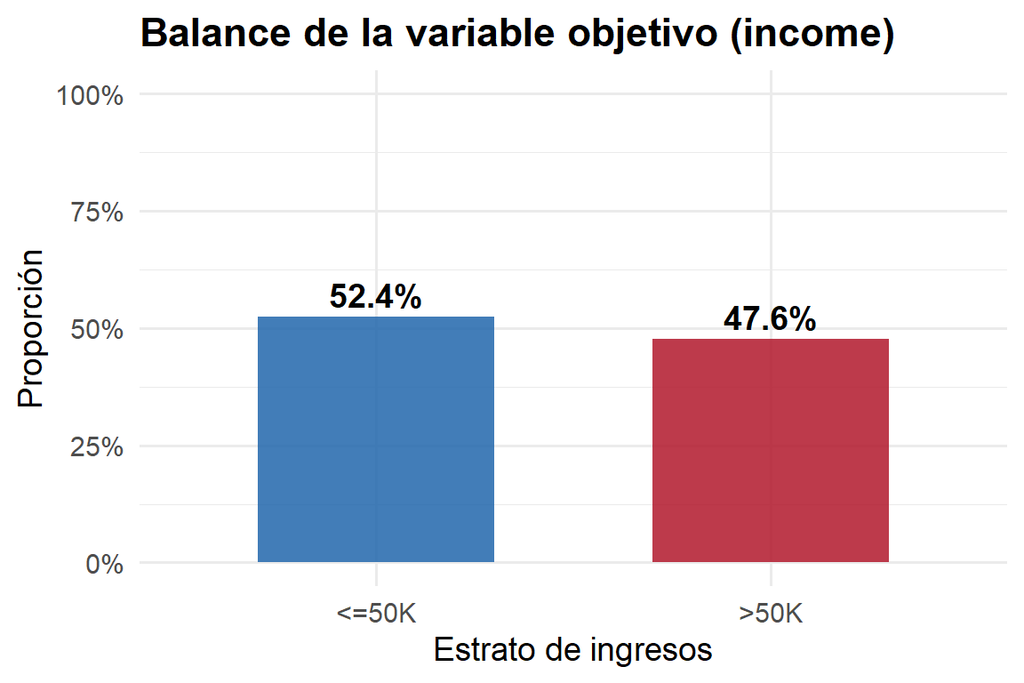

Figura 1

```r
datos |>
  count(income) |>
  mutate(prop = n / sum(n)) |>
  ggplot(aes(x = income, y = prop, fill = income)) +
  geom_col(alpha = 0.85, width = 0.6) +
  geom_text(aes(label = scales::label_percent(accuracy = 0.1)(prop)),
            vjust = -0.4, fontface = "bold") +
  scale_fill_manual(values = paleta_ingresos, guide = "none") +
  scale_y_continuous(labels = scales::label_percent(), limits = c(0, 1)) +
  labs(title = "Balance de la variable objetivo (income)",
       x = "Estrato de ingresos", y = "Proporción") +
  theme_minimal(base_size = 14) +
  theme(plot.title = element_text(face = "bold"))
```

**Nota**

**Balance verificado.** Los datos están casi perfectamente equilibrados (≈ 52% / 48%), un escenario análogo al del tutorial 10 (51% / 49%). Esto es muy favorable para el ajuste e interpretación del modelo logístico.

# Análisis exploratorio y decisiones de transformación

## Variables continuas vs. `income`

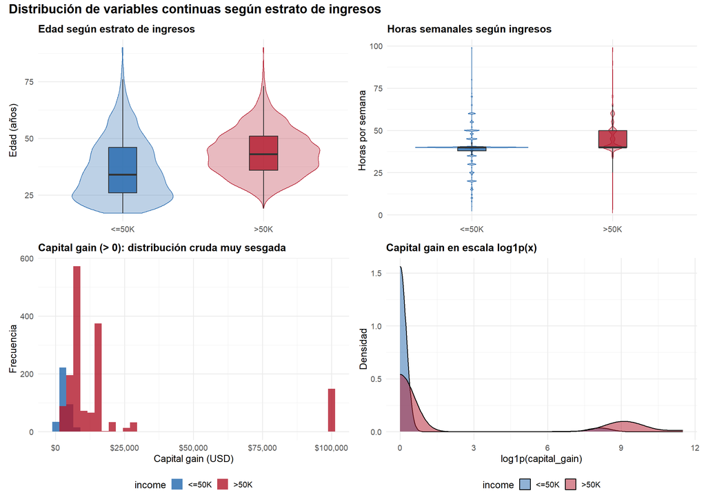

Figura 2

```r
p_age <- datos |>
  ggplot(aes(x = income, y = age, fill = income, color = income)) +
  geom_violin(alpha = 0.3, linewidth = 0.5, width = 0.8) +
  geom_boxplot(width = 0.2, alpha = 0.8, color = "gray20", outlier.shape = NA) +
  scale_fill_manual(values = paleta_ingresos, guide = "none") +
  scale_color_manual(values = paleta_ingresos, guide = "none") +
  labs(title = "Edad según estrato de ingresos", x = NULL, y = "Edad (años)") +
  theme_minimal(base_size = 14) +
  theme(plot.title = element_text(face = "bold", size = 15))

p_hours <- datos |>
  ggplot(aes(x = income, y = hours_per_week, fill = income, color = income)) +
  geom_violin(alpha = 0.3, linewidth = 0.5, width = 0.8) +
  geom_boxplot(width = 0.2, alpha = 0.8, color = "gray20", outlier.shape = NA) +
  scale_fill_manual(values = paleta_ingresos, guide = "none") +
  scale_color_manual(values = paleta_ingresos, guide = "none") +
  labs(title = "Horas semanales según ingresos", x = NULL, y = "Horas por semana") +
  theme_minimal(base_size = 14) +
  theme(plot.title = element_text(face = "bold", size = 15))

p_capgain <- datos |>
  filter(capital_gain > 0) |>
  ggplot(aes(x = capital_gain, fill = income)) +
  geom_histogram(bins = 40, alpha = 0.8, position = "identity") +
  scale_fill_manual(values = paleta_ingresos, name = "income") +
  scale_x_continuous(labels = scales::label_dollar()) +
  labs(title = "Capital gain (> 0): distribución cruda muy sesgada",
       x = "Capital gain (USD)", y = "Frecuencia") +
  theme_minimal(base_size = 14) +
  theme(plot.title = element_text(face = "bold", size = 15),
        legend.position = "bottom")

p_capgain_log <- datos |>
  ggplot(aes(x = log1p(capital_gain), fill = income)) +
  geom_density(alpha = 0.5, linewidth = 0.7) +
  scale_fill_manual(values = paleta_ingresos, name = "income") +
  labs(title = "Capital gain en escala log1p(x)",
       x = "log1p(capital_gain)", y = "Densidad") +
  theme_minimal(base_size = 14) +
  theme(plot.title = element_text(face = "bold", size = 15),
        legend.position = "bottom")

(p_age | p_hours) / (p_capgain | p_capgain_log) +
  plot_annotation(
    title = "Distribución de variables continuas según estrato de ingresos",
    theme = theme(plot.title = element_text(face = "bold", size = 18))
  )
```

**Tip**

## Justificación de la transformación logarítmica

`capital_gain` y `capital_loss` son variables monetarias con **fuerte asimetría positiva** y **muchos ceros**. Aplicar `log1p(x) = log(x + 1)`:

- **comprime la cola** (los outliers dejan de dominar la pendiente del modelo) y
- **maneja los ceros sin discontinuidad** (a diferencia de `log(x)`, indefinido en 0).

Teóricamente tiene sentido modelar el efecto del capital de forma **multiplicativa / con rendimientos marginalmente decrecientes**.

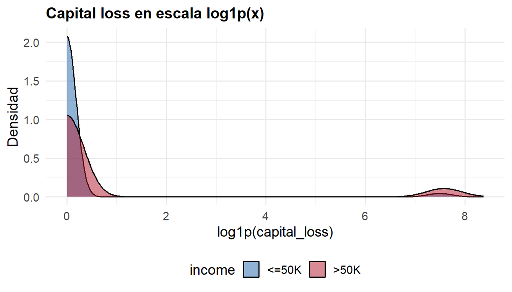

Figura 3

```r
datos |>
  ggplot(aes(x = log1p(capital_loss), fill = income)) +
  geom_density(alpha = 0.5, linewidth = 0.7) +
  scale_fill_manual(values = paleta_ingresos, name = "income") +
  labs(title = "Capital loss en escala log1p(x)",
       x = "log1p(capital_loss)", y = "Densidad") +
  theme_minimal(base_size = 14) +
  theme(plot.title = element_text(face = "bold", size = 15),
        legend.position = "bottom")
```

## Variables categóricas vs. `income`

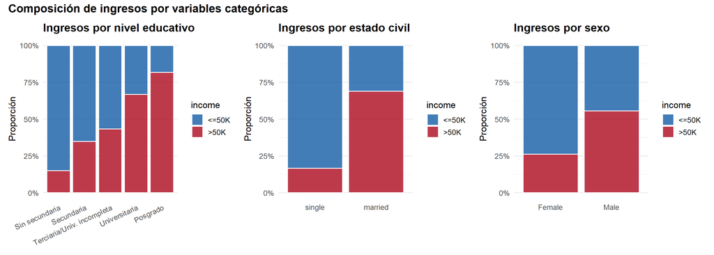

Figura 4

```r
p_edu <- datos |>
  ggplot(aes(x = educacion, fill = income)) +
  geom_bar(position = "fill", alpha = 0.85, color = "white") +
  scale_fill_manual(values = paleta_ingresos, name = "income") +
  scale_y_continuous(labels = scales::label_percent()) +
  labs(title = "Ingresos por nivel educativo", x = NULL, y = "Proporción") +
  theme_minimal(base_size = 13) +
  theme(plot.title = element_text(face = "bold"),
        axis.text.x = element_text(angle = 25, hjust = 1),
        panel.grid.major.x = element_blank())

p_mar <- datos |>
  ggplot(aes(x = marital_simple, fill = income)) +
  geom_bar(position = "fill", alpha = 0.85, color = "white") +
  scale_fill_manual(values = paleta_ingresos, name = "income") +
  scale_y_continuous(labels = scales::label_percent()) +
  labs(title = "Ingresos por estado civil", x = NULL, y = "Proporción") +
  theme_minimal(base_size = 13) +
  theme(plot.title = element_text(face = "bold"),
        panel.grid.major.x = element_blank())

p_sex <- datos |>
  ggplot(aes(x = sex, fill = income)) +
  geom_bar(position = "fill", alpha = 0.85, color = "white") +
  scale_fill_manual(values = paleta_ingresos, name = "income") +
  scale_y_continuous(labels = scales::label_percent()) +
  labs(title = "Ingresos por sexo", x = NULL, y = "Proporción") +
  theme_minimal(base_size = 13) +
  theme(plot.title = element_text(face = "bold"),
        panel.grid.major.x = element_blank())

(p_edu | p_mar | p_sex) +
  plot_annotation(
    title = "Composición de ingresos por variables categóricas",
    theme = theme(plot.title = element_text(face = "bold", size = 16))
  )
```

**Tip**

**Lectura de las categóricas**

- **Educación:** gradiente monótono perfecto. La proporción de `>50K` crece de ~15% en “Sin secundaria” hasta ~80% en “Posgrado”. Retorno educativo muy fuerte.
- **Estado civil:** brecha enorme. Solteros: ~17% son `>50K`. Casados: ~70%. Prima del matrimonio de +53 pp en términos brutos.
- **Sexo:** brecha de género clara. Mujeres: ~26% son `>50K`. Hombres: ~55%. Diferencia bruta de +29 pp.

## Justificación teórica de la interacción `sex × marital_simple`

Se propone como interacción **sexo × estado civil**. La hipótesis teórica de partida es el “modelo del varón proveedor”: históricamente, el matrimonio se asoció en EE. UU. con una mayor dedicación de los hombres al mercado laboral y un retiro relativo de las mujeres. Bajo esa lectura esperaríamos que **la prima del matrimonio fuera mayor en hombres**. Si la dinámica es esa (o su opuesto), el efecto del matrimonio **no se explica sumando** los efectos aislados.

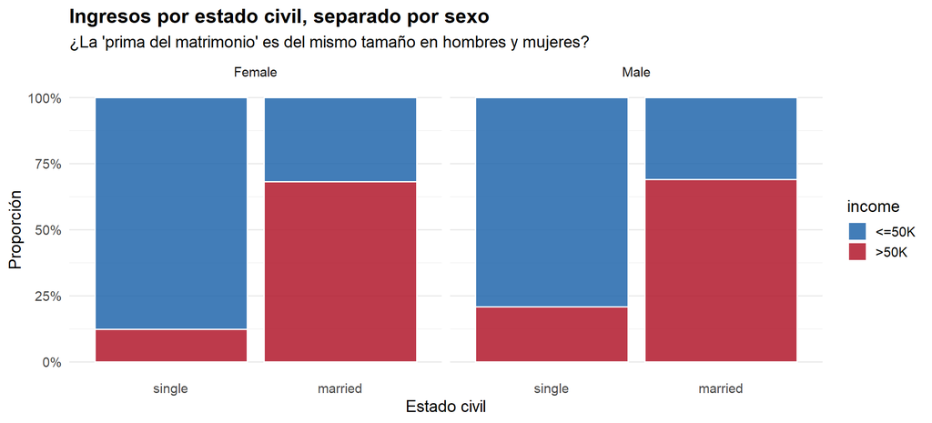

Figura 5

```r
datos |>
  ggplot(aes(x = marital_simple, fill = income)) +
  geom_bar(position = "fill", alpha = 0.85, color = "white") +
  facet_wrap(~ sex) +
  scale_fill_manual(values = paleta_ingresos, name = "income") +
  scale_y_continuous(labels = scales::label_percent()) +
  labs(
    title = "Ingresos por estado civil, separado por sexo",
    subtitle = "¿La 'prima del matrimonio' es del mismo tamaño en hombres y mujeres?",
    x = "Estado civil", y = "Proporción"
  ) +
  theme_minimal(base_size = 14) +
  theme(plot.title = element_text(face = "bold"),
        panel.grid.major.x = element_blank())
```

**Tip**

# Ajuste de modelos logísticos

Usamos `glm()` con `family = binomial`, que modela el **logaritmo de las chances (*log-odds*)** de que `income = ">50K"`:

$$\ln\!\left(\frac{P(Y=1)}{1-P(Y=1)}\right) = \beta_0 + \beta_1 X_1 + \dots + \beta_k X_k$$

Dos modelos:

- **Modelo 1 (Base):** edad + educación + estado civil + sexo + horas + log1p(capital).
- **Modelo 2 (Interactivo):** Modelo 1 + interacción `sex * marital_simple`.

```r
modelo_base <- glm(
  income ~ age + educacion + marital_simple + sex +
    hours_per_week + log1p(capital_gain) + log1p(capital_loss),
  family = binomial,
  data = datos
)

modelo_int <- glm(
  income ~ age + educacion + sex * marital_simple +
    hours_per_week + log1p(capital_gain) + log1p(capital_loss),
  family = binomial,
  data = datos
)

summary(modelo_base)
```

```
Call:
glm(formula = income ~ age + educacion + marital_simple + sex +
    hours_per_week + log1p(capital_gain) + log1p(capital_loss),
    family = binomial, data = datos)

Coefficients:
                                     Estimate Std. Error z value Pr(>|z|)
(Intercept)                         -6.713927   0.161567 -41.555  < 2e-16 ***
age                                  0.033787   0.001900  17.787  < 2e-16 ***
educacionSecundaria                  1.170840   0.091711  12.767  < 2e-16 ***
educacionTerciaria/Univ. incompleta  1.800487   0.093083  19.343  < 2e-16 ***
educacionUniversitaria               2.781154   0.098536  28.225  < 2e-16 ***
educacionPosgrado                    3.341321   0.111261  30.031  < 2e-16 ***
marital_simplemarried                2.355416   0.053047  44.403  < 2e-16 ***
sexMale                              0.213788   0.056238   3.802 0.000144 ***
hours_per_week                       0.034176   0.002113  16.175  < 2e-16 ***
log1p(capital_gain)                  0.207046   0.008740  23.690  < 2e-16 ***
log1p(capital_loss)                  0.157370   0.012783  12.311  < 2e-16 ***
---
Signif. codes:  0 '***' 0.001 '**' 0.01 '*' 0.05 '.' 0.1 ' ' 1

(Dispersion parameter for binomial family taken to be 1)

    Null deviance: 21821  on 15765  degrees of freedom
Residual deviance: 13420  on 15755  degrees of freedom
AIC: 13442

Number of Fisher Scoring iterations: 5
```

```r
cat("\n\n=============================================\n\n")
summary(modelo_int)
```

```
Call:
glm(formula = income ~ age + educacion + sex * marital_simple +
    hours_per_week + log1p(capital_gain) + log1p(capital_loss),
    family = binomial, data = datos)

Coefficients:
                                     Estimate Std. Error z value Pr(>|z|)
(Intercept)                         -7.181750   0.171745 -41.816   <2e-16 ***
age                                  0.035995   0.001929  18.656   <2e-16 ***
educacionSecundaria                  1.164402   0.091661  12.703   <2e-16 ***
educacionTerciaria/Univ. incompleta  1.799638   0.093041  19.342   <2e-16 ***
educacionUniversitaria               2.777306   0.098519  28.190   <2e-16 ***
educacionPosgrado                    3.355680   0.111729  30.034   <2e-16 ***
sexMale                              0.762619   0.081222   9.389   <2e-16 ***
marital_simplemarried                3.145903   0.099979  31.466   <2e-16 ***
hours_per_week                       0.035888   0.002130  16.849   <2e-16 ***
log1p(capital_gain)                  0.206704   0.008793  23.509   <2e-16 ***
log1p(capital_loss)                  0.157600   0.012818  12.295   <2e-16 ***
sexMale:marital_simplemarried       -1.103468   0.115090  -9.588   <2e-16 ***
---
Signif. codes:  0 '***' 0.001 '**' 0.01 '*' 0.05 '.' 0.1 ' ' 1

(Dispersion parameter for binomial family taken to be 1)

    Null deviance: 21821  on 15765  degrees of freedom
Residual deviance: 13325  on 15754  degrees of freedom
AIC: 13349

Number of Fisher Scoring iterations: 5
```

**Precaución**

**Interpretación de los `summary()` en log-odds**

Los `Estimate` están en escala de log-odds. Por eso pasamos a (1) **Odds Ratios**, (2) **AME** y (3) probabilidades predichas.

- **AIC**: cae de 13.442 (Modelo 1) a 13.349 (Modelo 2), una mejora de 93 puntos. La regla del tutorial pide >10 → la evidencia es contundente.
- **Interacción `sexMale:marital_simplemarried` = -1.10** (p < 2e-16): negativa, altamente significativa. La prima del matrimonio **se atenúa en hombres**: una vez controlados edad, educación, horas y capital, resulta **mayor en mujeres que en hombres**, contradiciendo la hipótesis del “varón proveedor”.
- **Todos los predictores** son significativos a p < 2e-16.

# De *log-odds* a Odds Ratios (Modelo 2)

Una *odd* (chance) es $p/(1-p)$. Exponenciando un coeficiente obtenemos el **Odds Ratio (OR)**, el factor multiplicativo sobre las chances al aumentar el predictor en una unidad:

- **OR > 1** → la variable **aumenta** las chances de `>50K`.
- **OR < 1** → la variable **reduce** las chances.
- **OR = 1** → efecto **neutro**.

```r
or_modelo <- broom::tidy(modelo_int, exponentiate = TRUE, conf.int = TRUE) |>
  select(term, estimate, conf.low, conf.high, p.value) |>
  mutate(
    interpretacion = case_when(
      estimate > 1 & p.value < 0.05 ~ "Aumenta chances (Sig.)",
      estimate < 1 & p.value < 0.05 ~ "Reduce chances (Sig.)",
      TRUE                          ~ "No significativo"
    )
  )

or_modelo |>
  rename(
    Predictor = term, `Odds Ratio` = estimate,
    `IC Inferior` = conf.low, `IC Superior` = conf.high,
    `Valor p` = p.value, `Interpretación` = interpretacion
  ) |>
  knitr::kable(digits = 3, caption = "Odds Ratios — Modelo 2 (Interactivo)") |>
  kable_styling(
    bootstrap_options = c("striped", "hover", "condensed", "responsive"),
    full_width = FALSE, position = "center"
  ) |>
  row_spec(which(or_modelo$p.value < 0.05),
           bold = TRUE, color = "black", background = "#e6f2ff")
```

Odds Ratios — Modelo 2 (Interactivo)

| Predictor | Odds Ratio | IC Inferior | IC Superior | Valor p | Interpretación |
| --- | --- | --- | --- | --- | --- |
| (Intercept) | 0.001 | 0.001 | 0.001 | 0 | Reduce chances (Sig.) |
| age | 1.037 | 1.033 | 1.041 | 0 | Aumenta chances (Sig.) |
| educacionSecundaria | 3.204 | 2.681 | 3.841 | 0 | Aumenta chances (Sig.) |
| educacionTerciaria/Univ. incompleta | 6.047 | 5.048 | 7.270 | 0 | Aumenta chances (Sig.) |
| educacionUniversitaria | 16.076 | 13.275 | 19.534 | 0 | Aumenta chances (Sig.) |
| educacionPosgrado | 28.665 | 23.069 | 35.750 | 0 | Aumenta chances (Sig.) |
| sexMale | 2.144 | 1.829 | 2.515 | 0 | Aumenta chances (Sig.) |
| marital_simplemarried | 23.241 | 19.129 | 28.309 | 0 | Aumenta chances (Sig.) |
| hours_per_week | 1.037 | 1.032 | 1.041 | 0 | Aumenta chances (Sig.) |
| log1p(capital_gain) | 1.230 | 1.209 | 1.251 | 0 | Aumenta chances (Sig.) |
| log1p(capital_loss) | 1.171 | 1.142 | 1.201 | 0 | Aumenta chances (Sig.) |
| sexMale:marital_simplemarried | 0.332 | 0.265 | 0.415 | 0 | Reduce chances (Sig.) |

**Tip**

**Lectura de los Odds Ratios significativos**

- **Educación**: gradiente monótono enorme. Secundaria multiplica las chances por ~3.2; Universitaria, por ~16; Posgrado, por ~29. El **predictor más fuerte**.
- **`marital_simplemarried` (OR ≈ 23):** efecto del matrimonio **en mujeres** (la referencia de sexo). Casarse multiplica por 23 las chances de `>50K` para una mujer.
- **`sexMale` (OR ≈ 2.14):** efecto de ser hombre **entre solteros**. Multiplica por ~2.1.
- **`sexMale:marital_simplemarried` (OR ≈ 0.33):** la interacción **reduce** las chances cuando se combinan los dos atributos. Combinando todo:
  - Mujer casada vs mujer soltera: OR ≈ **23** (prima enorme en mujeres).
  - Hombre casado vs mujer soltera: OR ≈ 2.14 × 23.24 × 0.332 ≈ **16.5** (prima más modesta en hombres).
- **`age`, `hours_per_week`**: OR ≈ 1.04 → cada unidad +4% de chances.
- **`log1p(capital_gain)`, `log1p(capital_loss)`**: ambos > 1 y significativos.

**Hallazgo principal:** la prima del matrimonio es **~3 veces más fuerte en mujeres que en hombres** una vez controlados los demás predictores, **contradiciendo** la hipótesis del varón proveedor.

# Efectos Marginales Promedio (AME)- Modelo 2

Mientras que los OR hablan en términos de “chances”; los **AME** traducen el efecto de cada predictor a **puntos porcentuales de probabilidad**, una métrica más natural. `marginaleffects::avg_slopes()` calcula el efecto exacto para *cada observación* y promedia.

```r
ame <- marginaleffects::avg_slopes(modelo_int)

ame |>
  as_tibble() |>
  select(term, contrast, estimate, conf.low, conf.high, p.value) |>
  mutate(
    `Efecto (pp)` = paste0(round(estimate * 100, 2), " pp"),
    Interpretación = case_when(
      estimate > 0 & p.value < 0.05 ~ "Aumenta prob. (Sig.)",
      estimate < 0 & p.value < 0.05 ~ "Reduce prob. (Sig.)",
      TRUE                          ~ "No significativo"
    )
  ) |>
  select(term, contrast, `Efecto (pp)`, conf.low, conf.high, p.value, Interpretación) |>
  rename(
    Predictor = term, Contraste = contrast,
    `IC Inferior` = conf.low, `IC Superior` = conf.high,
    `Valor p` = p.value
  ) |>
  knitr::kable(
    digits = 4,
    caption = "Efectos Marginales Promedio (cambio en probabilidad de >50K)"
  ) |>
  kable_styling(
    bootstrap_options = c("striped", "hover", "condensed", "responsive"),
    full_width = FALSE, position = "center"
  ) |>
  row_spec(
    which(ame$p.value < 0.05),
    bold = TRUE, color = "black", background = "#e6f2ff"
  )
```

Efectos Marginales Promedio (cambio en probabilidad de >50K)

| Predictor | Contraste | Efecto (pp) | IC Inferior | IC Superior | Valor p | Interpretación |
| --- | --- | --- | --- | --- | --- | --- |
| age | dY/dX | 0.49 pp | 0.0044 | 0.0054 | 0.0000 | Aumenta prob. (Sig.) |
| capital_gain | dY/dX | 0 pp | 0.0000 | 0.0000 | 0.0000 | Aumenta prob. (Sig.) |
| capital_loss | dY/dX | 2.07 pp | 0.0174 | 0.0240 | 0.0000 | Aumenta prob. (Sig.) |
| educacion | Posgrado - Sin secundaria | 48.15 pp | 0.4546 | 0.5084 | 0.0000 | Aumenta prob. (Sig.) |
| educacion | Secundaria - Sin secundaria | 16.34 pp | 0.1406 | 0.1862 | 0.0000 | Aumenta prob. (Sig.) |
| educacion | Terciaria/Univ. incompleta - Sin secundaria | 26.17 pp | 0.2386 | 0.2848 | 0.0000 | Aumenta prob. (Sig.) |
| educacion | Universitaria - Sin secundaria | 40.5 pp | 0.3810 | 0.4289 | 0.0000 | Aumenta prob. (Sig.) |
| hours_per_week | dY/dX | 0.49 pp | 0.0043 | 0.0055 | 0.0000 | Aumenta prob. (Sig.) |
| marital_simple | married - single | 37.78 pp | 0.3624 | 0.3932 | 0.0000 | Aumenta prob. (Sig.) |
| sex | Male - Female | -0.07 pp | -0.0165 | 0.0151 | 0.9278 | No significativo |

**Nota**

**Interpretación directa (AME) con valores reales**

# Forest plot de Odds Ratios- Modelo 2

Se muestran los OR del Modelo 2 con **intervalos de confianza graduados** a 80%, 95% y 99%. Calculamos los intervalos manualmente desde `std.error` y los presentamos en **escala logarítmica** en X (clave: hace que “la mitad de chances” quede tan lejos del 1 como “el doble”). Línea de referencia en `OR = 1`.

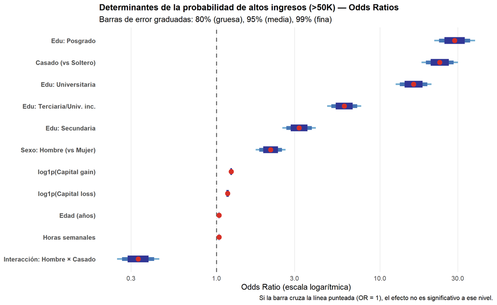

Figura 6

```r
df_plot_or <- broom::tidy(modelo_int) |>
  filter(term != "(Intercept)") |>
  mutate(
    lo_80 = estimate - qnorm(0.90)  * std.error, hi_80 = estimate + qnorm(0.90)  * std.error,
    lo_95 = estimate - qnorm(0.975) * std.error, hi_95 = estimate + qnorm(0.975) * std.error,
    lo_99 = estimate - qnorm(0.995) * std.error, hi_99 = estimate + qnorm(0.995) * std.error,
    across(c(estimate, starts_with("lo_"), starts_with("hi_")), exp),
    term_clean = case_match(
      term,
      "age"                                  ~ "Edad (años)",
      "hours_per_week"                       ~ "Horas semanales",
      "log1p(capital_gain)"                  ~ "log1p(Capital gain)",
      "log1p(capital_loss)"                  ~ "log1p(Capital loss)",
      "educacionSecundaria"                  ~ "Edu: Secundaria",
      "educacionTerciaria/Univ. incompleta"  ~ "Edu: Terciaria/Univ. inc.",
      "educacionUniversitaria"               ~ "Edu: Universitaria",
      "educacionPosgrado"                    ~ "Edu: Posgrado",
      "sexMale"                              ~ "Sexo: Hombre (vs Mujer)",
      "marital_simplemarried"                ~ "Casado (vs Soltero)",
      "sexMale:marital_simplemarried"        ~ "Interacción: Hombre × Casado",
      .default = term
    )
  )

ggplot(df_plot_or, aes(y = reorder(term_clean, estimate), x = estimate)) +
  geom_vline(xintercept = 1, linetype = "dashed", color = "gray40", linewidth = 1) +
  geom_linerange(aes(xmin = lo_99, xmax = hi_99), color = "#74ADD1", linewidth = 1.5) +
  geom_linerange(aes(xmin = lo_95, xmax = hi_95), color = "#4575B4", linewidth = 3.5) +
  geom_linerange(aes(xmin = lo_80, xmax = hi_80), color = "#313695", linewidth = 6) +
  geom_point(color = "#D73027", size = 4) +
  scale_x_log10() +
  labs(
    title = "Determinantes de la probabilidad de altos ingresos (>50K) — Odds Ratios",
    subtitle = "Barras de error graduadas: 80% (gruesa), 95% (media), 99% (fina)",
    x = "Odds Ratio (escala logarítmica)", y = NULL,
    caption = "Si la barra cruza la línea punteada (OR = 1), el efecto no es significativo a ese nivel."
  ) +
  theme_minimal(base_size = 15) +
  theme(
    plot.title = element_text(face = "bold", size = 16),
    panel.grid.minor = element_blank(),
    panel.grid.major.y = element_blank(),
    axis.text.y = element_text(face = "bold", size = 12)
  )
```

**Nota**

**Lectura del forest plot**

- **Educación**: gradiente monótono perfectamente representado, culminando en `Posgrado` con OR ≈ 29.
- **`Casado (vs Soltero)`** (OR ≈ 23): efecto del matrimonio entre **mujeres**. Enorme.
- **`Sexo: Hombre (vs Mujer)`** (OR ≈ 2.14): efecto del sexo entre **solteros**.
- **`Interacción: Hombre × Casado`** (OR ≈ 0.33): único predictor a la **izquierda** de OR = 1. La prima del matrimonio se atenúa en hombres.
- **Edad, horas, capital gain y capital loss** cerca del 1, con barras angostas: efectos pequeños por unidad pero **altamente significativos**.
- **Ningún coeficiente cruza el OR = 1 a ningún nivel de confianza** (80/95/99): inferencia muy robusta gracias al tamaño muestral (~15.766 obs.).

# Visualización de la interacción `sex × marital_simple`

Los coeficientes de interacción son difíciles de interpretar directamente. La forma más clara de entenderlos es graficar las **probabilidades predichas** del modelo según los valores de las dos variables que interactúan, comparando el Modelo Base (sin interacción) con el Modelo Interactivo. Esto muestra el **efecto real en probabilidades**, no en log-odds o chances.

`marginaleffects::plot_predictions()` calcula la probabilidad predicha de `>50K` para cada combinación de `marital_simple × sex`, manteniendo el resto de las variables en su media/moda automáticamente.

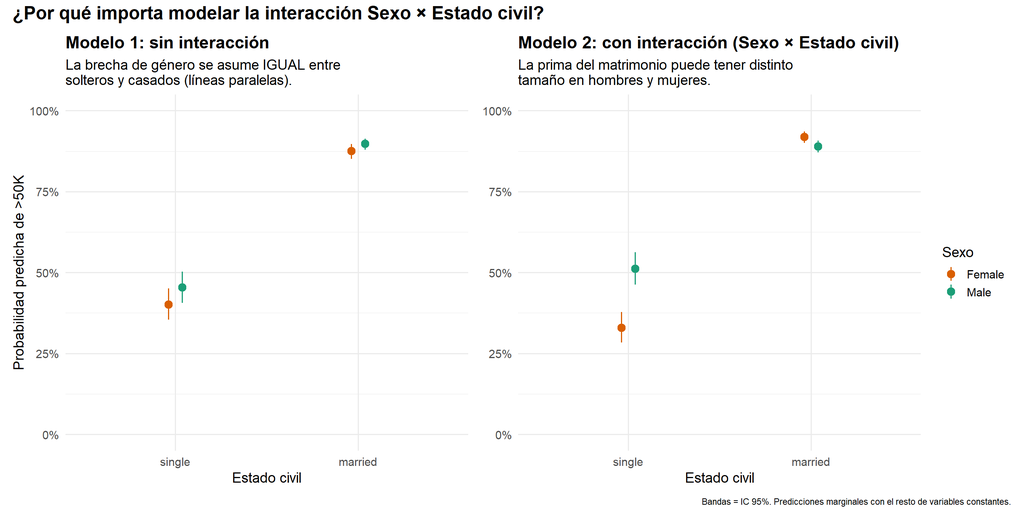

Figura 7

```r
# Predicciones marginales del Modelo Base (sin interacción).
# Por construcción, la distancia entre hombres y mujeres es la MISMA en solteros y casados.
p_base <- plot_predictions(modelo_base, condition = c("marital_simple", "sex")) +
  scale_color_manual(values = c("Female" = "#D95F02", "Male" = "#1B9E77"), name = "Sexo") +
  scale_fill_manual(values = c("Female" = "#D95F02", "Male" = "#1B9E77"), name = "Sexo") +
  scale_y_continuous(labels = scales::label_percent(), limits = c(0, 1)) +
  labs(
    title = "Modelo 1: sin interacción",
    subtitle = "La brecha de género se asume IGUAL entre\nsolteros y casados (líneas paralelas).",
    x = "Estado civil", y = "Probabilidad predicha de >50K"
  ) +
  theme_minimal(base_size = 14) +
  theme(plot.title = element_text(face = "bold"), legend.position = "none")

# Predicciones marginales del Modelo Interactivo.
# Al liberar la restricción, la brecha de género puede variar según el estado civil.
p_int <- plot_predictions(modelo_int, condition = c("marital_simple", "sex")) +
  scale_color_manual(values = c("Female" = "#D95F02", "Male" = "#1B9E77"), name = "Sexo") +
  scale_fill_manual(values = c("Female" = "#D95F02", "Male" = "#1B9E77"), name = "Sexo") +
  scale_y_continuous(labels = scales::label_percent(), limits = c(0, 1)) +
  labs(
    title = "Modelo 2: con interacción (Sexo × Estado civil)",
    subtitle = "La prima del matrimonio puede tener distinto\ntamaño en hombres y mujeres.",
    x = "Estado civil", y = NULL
  ) +
  theme_minimal(base_size = 14) +
  theme(plot.title = element_text(face = "bold"))

# Combinamos los dos paneles con patchwork
p_base + p_int +
  plot_annotation(
    title = "¿Por qué importa modelar la interacción Sexo × Estado civil?",
    caption = "Bandas = IC 95%. Predicciones marginales con el resto de variables constantes.",
    theme = theme(plot.title = element_text(face = "bold", size = 18))
  )
```

**Nota**

**La interacción se vuelve clara en probabilidades**

En el **Modelo 2** (panel derecho), al liberar esa restricción, el patrón real emerge:

- **Entre solteros**, los hombres tienen una probabilidad de `>50K` mayor que las mujeres (la línea verde queda más arriba que la naranja).
- **Entre casados**, las dos líneas casi convergen — incluso podría revertirse el signo (la mujer casada puede tener probabilidad ligeramente mayor o igual al hombre casado, dependiendo del resto de los predictores).
- Es decir, el salto de soltero a casado es muchísimo mayor en mujeres que en hombres. Esa es la prima del matrimonio asimétrica que ya habían anticipado los Odds Ratios.

En EE. UU., una mujer casada que aún participa del mercado laboral full-time pertenece a un grupo fuertemente seleccionado (modelo de “doble carrera” / hogares de altos ingresos), mientras que el matrimonio no transforma tanto la posición laboral de los hombres porque ya están masivamente en el mercado tanto solteros como casados.

## Interpretación de las variables significativas y de la interacción en probabilidades

Resumen de los efectos en términos **interpretables**, integrando los OR y AME presentados:

- **Educación (efecto más fuerte del modelo)**: cada escalón educativo eleva la probabilidad de `>50K` de forma marcada. Tener **posgrado** suma **48.2 pp** respecto de no terminar el secundario; tener **diploma universitario**, **40.5 pp**. Es un retorno monótono y consistente.
- **Estado civil**: casarse asocia un salto promedio de **+37.8 pp** de probabilidad de `>50K`. La prima es de **+53 pp en términos brutos**, pero al controlar por edad, educación, horas y capital se sigue manteniendo enorme.
- **Edad y horas trabajadas**: efectos individuales chicos (~0.5 pp por año / por hora) pero **acumulativos y altamente significativos**. Diez años de edad o 10 horas semanales más suman ~5 pp de probabilidad.
- **Capital gain y capital loss**: ambos asociados positivamente con `>50K`. Tener pérdidas de capital declarado correlaciona con altos ingresos porque solo quienes tienen cartera invertida pueden tener pérdidas declaradas.
- **Sexo en términos absolutos**: el AME promedio es prácticamente cero (-0.07 pp, p = 0.928), pero **no porque el sexo no importe**, sino porque los efectos opuestos del sexo en solteros vs casados se cancelan al promediar. La interacción captura toda la dinámica.
- **Interacción Sexo × Estado civil**: la prima del matrimonio es **mucho mayor en mujeres que en hombres** una vez controlados los demás predictores, contradiciendo la hipótesis inicial del “varón proveedor”.

# Comparación global de modelos

Hasta este punto se interpretó el Modelo 2 (con interacción), pero la consigna pide compararlo formalmente con el Modelo 1 (sin interacción) para decidir si vale la pena la complejidad adicional. Usamos `broom::glance()` para extraer las métricas de ajuste de cada modelo y las apilamos en una tabla.

Podemos ver: - **Deviance nula:** información que le falta a un modelo que solo usa el intercepto. - **Deviance residual:** información que le falta al modelo completo. - **Pseudo-R² (McFadden):** calculado como $1 - \frac{\text{deviance residual}}{\text{deviance nula}}$. Su interpretación es análoga a la del $R^2$ de OLS. - **AIC** (*Akaike Information Criterion*): menor valor indica mejor ajuste penalizando complejidad. Una caída superior a 10 puntos ya es indicio claro de que el modelo más complejo es preferible.

```r
bind_rows(
  broom::glance(modelo_base) |> mutate(Modelo = "1. Sin interacción"),
  broom::glance(modelo_int)  |> mutate(Modelo = "2. Con interacción")
) |>
  # Pseudo-R² de McFadden a partir de las deviances (versión del tutorial 10):
  #   pseudo_r2 = 1 - (deviance residual / deviance nula)
  mutate(pseudo_r2 = 1 - (deviance / null.deviance)) |>
  # Ordenamos las columnas para reporte
  select(Modelo, null.deviance, deviance, pseudo_r2, AIC, nobs) |>
  rename(
    `Deviance Nula`     = null.deviance,
    `Deviance Residual` = deviance,
    `Pseudo-R²`         = pseudo_r2,
    `Observaciones`     = nobs
  ) |>
  knitr::kable(
    digits  = c(0, 1, 1, 4, 1, 0),
    caption = "Métricas de ajuste global (datos completos)"
  ) |>
  kable_styling(
    bootstrap_options = c("striped", "hover", "condensed", "responsive"),
    full_width = FALSE, position = "center"
  ) |>
  # Resaltamos la fila del modelo ganador (el Modelo 2)
  row_spec(2, bold = TRUE, color = "black", background = "#e6f2ff")
```

Métricas de ajuste global (datos completos)

| Modelo | Deviance Nula | Deviance Residual | Pseudo-R² | AIC | Observaciones |
| --- | --- | --- | --- | --- | --- |
| 1. Sin interacción | 21820.6 | 13419.8 | 0.3850 | 13441.8 | 15766 |
| 2. Con interacción | 21820.6 | 13325.2 | 0.3893 | 13349.2 | 15766 |

**Importante**

**¿La interacción mejora el modelo?**

Comparando ambas filas de la tabla:

- **AIC:** baja de **13.442** (Modelo 1) a **13.349** (Modelo 2). Es una caída de **93 puntos**, muy por encima del umbral de 10 que sugiere la regla práctica del tutorial. La evidencia es contundente: el Modelo 2 ajusta sustancialmente mejor pese a tener un parámetro adicional.
- **Pseudo-R²:** crece de **0.385** (Modelo 1) a **0.389** (Modelo 2). Es una mejora modesta en términos absolutos (~0.4 pp), pero coherente con el AIC. Con muestras grandes (n ≈ 15.766) los Pseudo-R² cambian poco entre modelos anidados, así que el AIC es más sensible y suele ser la métrica decisiva.
- **Deviance residual:** baja de 13.420 a 13.325, una reducción de 95 puntos para un único grado de libertad adicional (el término de interacción). Una prueba de chi-cuadrado de razón de verosimilitud confirmaría que esta reducción es altamente significativa.

**Conclusión:** la inclusión de la interacción `sex × marital_simple` mejora claramente el modelo, tanto en términos estadísticos (AIC y deviance) como teóricos (permite ver que la prima del matrimonio difiere entre hombres y mujeres). El Modelo 2 es el modelo preferido para describir los determinantes de la probabilidad de altos ingresos en la muestra.

# Interpretación final

A partir del análisis presentado, se resumen los hallazgos sustantivos sobre los determinantes de la probabilidad de pertenecer al estrato de altos ingresos (`>50K`) en la muestra del *Adult Census Income* (n ≈ 15.766).

## Factores asociados con mayor probabilidad de altos ingresos

- **Educación**: el predictor más fuerte del modelo. La probabilidad de `>50K` aumenta monótonamente a cada escalón educativo. Tener posgrado suma **+48.2 puntos porcentuales** de probabilidad respecto de no haber terminado el secundario; un diploma universitario, **+40.5 pp**. Es un retorno educativo consistente y muy marcado.
- **Estado civil**: estar casado asocia **+37.8 pp** de probabilidad de `>50K` en promedio. La “prima del matrimonio” es uno de los efectos más grandes del modelo, comparable a tener educación universitaria.
- **Edad y horas semanales**: efectos pequeños por unidad (~0.5 pp por año / por hora) pero altamente significativos y acumulativos. Diez años o diez horas adicionales suman ~5 pp cada uno.
- **Capital gain y capital loss**: ambos correlacionan positivamente con `>50K`. Tener pérdidas declaradas indica tener capital invertido, marcador indirecto de altos ingresos.

## El rol de la interacción Sexo × Estado civil

El término de interacción **`sex × marital_simple`** resulta altamente significativo (p < 2e-16) y la inclusión de la interacción *mejora claramente* el ajuste (AIC: 13.442 → 13.349, reducción de 93 puntos). El hallazgo central es que **la prima del matrimonio es asimétrica entre sexos**:

- Para una **mujer**, casarse multiplica las chances de `>50K` por aproximadamente **23**.
- Para un **hombre**, casarse las multiplica por aproximadamente **7.7**.

La prima del matrimonio resulta así *alrededor de tres veces más fuerte en mujeres que en hombres* una vez controlados edad, educación, horas trabajadas y capital. Este resultado *contradice la hipótesis inicial* que habíamos planteado al proponer la interacción, que predeciría una prima mayor en hombres. Una lectura importante del hallazgo es que las mujeres casadas que aún participan del mercado laboral *full-time* con alta educación constituyen un grupo fuertemente seleccionado (modelo de “doble carrera”/hogares de altos ingresos), mientras que los hombres ya están masivamente en el mercado laboral tanto solteros como casados, de modo que el matrimonio no transforma tanto su probabilidad de pertenecer al estrato alto.

Otro resultado vinculado es que el **AME promedio del sexo es prácticamente cero** (-0.07 pp, p = 0.928): no porque el sexo no importe, sino porque sus efectos opuestos en solteros y casados **se cancelan al promediar**. Esto refuerza la importancia de haber incluido la interacción.

## Alcance del análisis

Las asociaciones que se reportaron son **correlacionales**, no causales. Describimos patrones en una muestra censal (rebalanceada por la cátedra a ~52/48), no efectos causales identificados: existen factores no observados (sector económico, tipo de empresa, trayectoria migratoria, características del hogar) que podrían sesgar las estimaciones puntuales. Las probabilidades predichas absolutas tampoco extrapolan a la población general de EE. UU., porque la muestra fue rebalanceada y la prevalencia real de `>50K` es menor.

Dicho esto, los **patrones cualitativos** (gradiente educativo, prima del matrimonio asimétrica, efectos pequeños pero acumulativos de edad y horas) son robustos: sobreviven al 99% de confianza, son consistentes con la literatura económica y se sostienen a través de los tres lentes -Odds Ratios, AME y probabilidades predichas- que aplicamos sucesivamente.